# countryatlas: Joining World Data to Maps on the ISO Spine

Youzhi Yu University of Chicago

# Abstract

Joining country-level data across independent sources is deceptively hard: the same country is spelled `"US"`, `"U.S."`, `"United States"` and `"United States of America"`, and a naïve join treats them as different entities. **countryatlas** resolves this friction by adopting ISO 3166 codes as a universal join key and by stitching together three otherwise disjoint resources (map geometry, World Bank development indicators, and a comprehensive country-code crosswalk) into a single, map-ready table. This vignette presents the package’s design philosophy, its core functional vocabulary, and worked examples spanning data assembly, the join engine, diagnostics, reference data, analysis helpers and the grammar of honest cartographic displays; the companion vignettes take up the remaining map types, projections and query interface in detail. All examples run offline against a bundled data snapshot.

# 1 Introduction

The package rests on a single conviction: *if a task does not make it easier to get country data onto a map, or to make that map honest, it does not belong here*. Concretely, three packages are combined:

- **`ggplot2::map_data("world")`** (or Natural Earth via `sf`) supplies polygon geometry, i.e. *where* countries are;
- **`WDI`** supplies World Bank indicators, i.e. *what is true* about them;
- **`countrycode`** supplies the crosswalk of ISO codes, continents and regions that makes a reliable join possible.

Three design commitments follow. First, **the happy path is one call**: `world_data(2020)` returns a tibble ready to map. Second, **the ISO code is the spine**: every function speaks `iso3c`/`iso2c` internally and exposes it, so anything the package produces joins to anything else, and to the user’s own data. Third, **no country is lost silently**: entities that map backends spell idiosyncratically are *matched* through a curated override table rather than dropped, and unmatched values are reported explicitly.

To keep every example reproducible without a network connection, this vignette uses the bundled `world_snapshot` dataset, a curated set of indicators for one recent year.

```r
snapshot <- world_snapshot$countries
dplyr::glimpse(snapshot)
```

```
#> Rows: 215
#> Columns: 10
#> $ iso3c           <chr> "AFG", "ALB", "DZA", "ASM", "AND", "AGO", "ATG", "ARG"…
#> $ iso2c           <chr> "AF", "AL", "DZ", "AS", "AD", "AO", "AG", "AR", "AM", …
#> $ country         <chr> "Afghanistan", "Albania", "Algeria", "American Samoa",…
#> $ continent       <chr> "Asia", "Europe", "Africa", "Oceania", "Europe", "Afri…
#> $ region          <chr> "South Asia", "Europe & Central Asia", "Middle East & …
#> $ income          <fct> Low income, Upper middle income, Upper middle income, …
#> $ gdp_per_capita  <dbl> NA, 6549.234, 4765.729, NA, 41034.527, 2845.478, 18350…
#> $ population      <dbl> 42647492, 2377128, 46814308, 46765, 81938, 37885849, 9…
#> $ life_expectancy <dbl> 66.28900, 79.77600, 76.47500, 72.99200, 84.18800, 64.8…
#> $ co2_per_capita  <dbl> 0.282980298, 1.785221494, 3.980800058, 0.002138351, NA…
```

# 2 Core data assembly

## 2.1 `world_data()`

The headline function is generalised but backward-compatible. The classic call returns the polygon-backed, enriched tibble exactly as before:

```r
# Live World Bank API call (not evaluated here to keep the vignette offline):
world_data(2020)
world_data(
  2020,
  indicator = c(life_exp = "SP.DYN.LE00.IN", co2 = "EN.GHG.CO2.PC.CE.AR5"),
  geometry  = "sf",
  region    = "Africa"
)
```

The `indicator` argument accepts one or many WDI codes; a **named** vector drives clean column names. A range of years (`2000:2020`) yields a panel keyed on `iso3c` and `year`. The `geometry` argument switches between the classic `"polygon"` backend, a modern `"sf"` backend with real projections, and `"none"` for pure analysis.

## 2.2 `country_data()` and `attach_geometry()`

For analysis you usually want one tidy row per country, not ~99,000 polygon vertices. `country_data()` provides exactly that, and geometry is attached only at draw time:

```r
mapdf <- attach_geometry(snapshot, geometry = "polygon")
dim(mapdf)
```

```
#> [1] 99338    15
```

# 3 Visualising: the choropleth and beyond

## 3.1 One-line choropleths

`world_map()` encapsulates the plotting boilerplate and offers several honest styles. A continuous fill on a skewed indicator hides most of the variation, so binned and quantile styles are first-class:

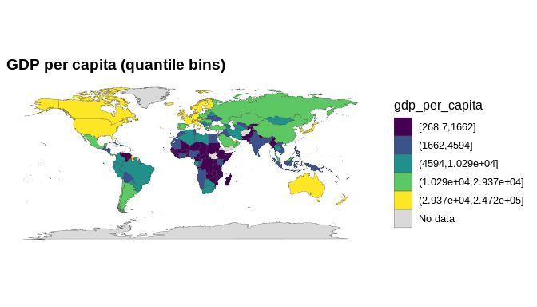

```r
world_map(mapdf, gdp_per_capita, style = "quantile",
          title = "GDP per capita (quantile bins)")
```

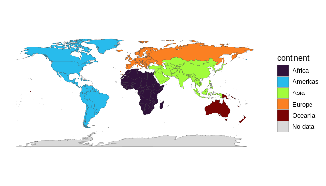

```r
world_map(mapdf, continent, style = "categorical")
```

## 3.2 Proportional-symbol maps

Totals (population, total emissions) are misrepresented by a choropleth because large values hide in small countries. A bubble map at country centroids is the right idiom:

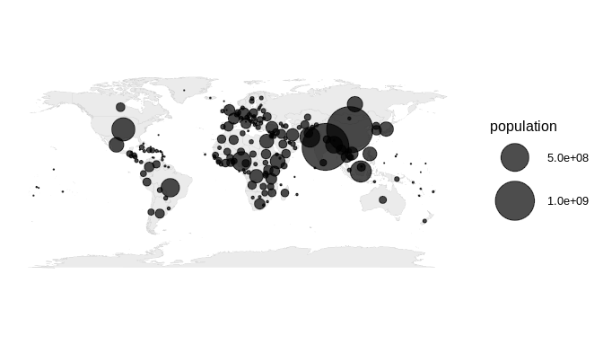

```r
bubble_map(snapshot, population)
```

## 3.3 Equal-area tile grids

Tiny states vanish on a geographic map. An equal-area tile grid gives every country the same visual weight:

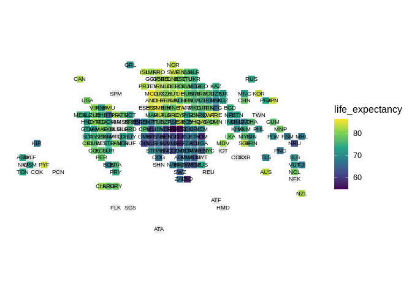

```r
tile_map(snapshot, life_expectancy)
```

## 3.4 Flow maps

Origin–destination data (trade, migration, flights) is drawn as great-circle arcs, with both endpoints resolved to centroids automatically:

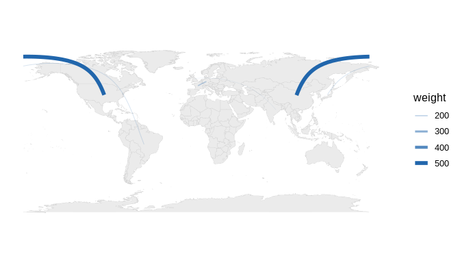

```r
flows <- data.frame(
  from   = c("China", "Germany", "Brazil", "India"),
  to     = c("United States", "France", "Japan", "United Kingdom"),
  weight = c(500, 200, 150, 120)
)
flow_map(flows, from, to, weight)
```

# 4 The join engine

The package’s mission, exposed for the reader’s own data. Given a frame keyed on messy names, `standardize_country()` attaches ISO codes and classifications:

```r
messy <- data.frame(
  nation = c("U.S.", "S. Korea", "Czechia", "Kosovo", "Cote d'Ivoire"),
  value  = c(10, 8, 6, 4, 7)
)
standardize_country(messy, nation, warn = FALSE)
```

```
#> # A tibble: 5 × 6
#>   nation        value iso3c iso2c continent region
#>   <chr>         <dbl> <chr> <chr> <chr>     <chr>
#> 1 U.S.             10 USA   US    Americas  North America
#> 2 S. Korea          8 KOR   KR    Asia      East Asia & Pacific
#> 3 Czechia           6 CZE   CZ    Europe    Europe & Central Asia
#> 4 Kosovo            4 XKX   XK    Europe    Europe & Central Asia
#> 5 Cote d'Ivoire     7 CIV   CI    Africa    Sub-Saharan Africa
```

`join_world()` goes one step further, auto-detecting the country column, standardising it and attaching geometry, while `country_join()` reconciles two independent tables that each key on country names:

```r
left  <- data.frame(country = c("Czechia", "South Korea"), gdp = c(1, 2))
right <- data.frame(nation  = c("Czech Republic", "Korea, Rep."), pop = c(10, 51))
country_join(left, right, country, nation)
```

```
#> # A tibble: 2 × 5
#>   country       gdp iso3c nation           pop
#>   <chr>       <dbl> <chr> <chr>          <dbl>
#> 1 Czechia         1 CZE   Czech Republic    10
#> 2 South Korea     2 KOR   Korea, Rep.       51
```

# 5 Diagnostics: never lose a country silently

`check_country_match()` is a pre-flight report; `country_overrides()` is the curated match table that replaces the old drop-list; and `audit_coverage()` reports missingness before a half-empty map is published.

```r
check_country_match(c("USA", "Cote d'Ivoire", "Yugoslavia", "Wakanda"))
```

```
#> # A tibble: 4 × 5
#>   input         iso3c matched historical suggestion
#>   <chr>         <chr> <lgl>   <lgl>      <chr>
#> 1 USA           USA   TRUE    FALSE      <NA>
#> 2 Cote d'Ivoire CIV   TRUE    FALSE      <NA>
#> 3 Yugoslavia    <NA>  FALSE   TRUE       Yugoslavia
#> 4 Wakanda       <NA>  FALSE   FALSE      Canada
```

`repair_country_names()` acts on that report: it substitutes the closest known country name for confident misses only, and attaches a record of every change:

```r
repair_country_names(c("Brzil", "Germny", "United States"), verbose = FALSE)
```

```
#> [1] "Brazil"        "Germany"       "United States"
#> attr(,"repairs")
#> # A tibble: 2 × 2
#>   from   to
#>   <chr>  <chr>
#> 1 Brzil  Brazil
#> 2 Germny Germany
```

```r
audit_coverage(snapshot)$na_rates
```

```
#> # A tibble: 4 × 4
#>   indicator           n n_missing na_rate
#>   <chr>           <int>     <int>   <dbl>
#> 1 gdp_per_capita    215        24  0.112
#> 2 population        215         0  0
#> 3 life_expectancy   215         0  0
#> 4 co2_per_capita    215        12  0.0558
```

The entities the previous version dropped (Kosovo, Micronesia, the Virgin Islands and a dozen others) are now matched:

```r
dropped <- c("Kosovo", "Micronesia", "Virgin Islands", "Canary Islands",
             "Saint Martin")
standardize_country(data.frame(region = dropped), region, warn = FALSE)
```

```
#> # A tibble: 5 × 4
#>   iso3c iso2c continent region
#>   <chr> <chr> <chr>     <chr>
#> 1 XKX   XK    Europe    Europe & Central Asia
#> 2 FSM   FM    Oceania   East Asia & Pacific
#> 3 VIR   VI    Americas  Latin America & Caribbean
#> 4 ESP   ES    Europe    Europe & Central Asia
#> 5 MAF   MF    Americas  Latin America & Caribbean
```

Dissolved entities get first-class treatment too. The `historical` column of `check_country_match()` flags them, including `"USSR"`, which countrycode silently resolves to Russia’s `RUS` (so Soviet-era data becomes Russian data without a warning), and `dissolve_country()` expands them to their successor states via the curated `historical_codes` crosswalk:

```r
check_country_match(c("USSR", "Czechoslovakia"))
```

```
#> # A tibble: 2 × 5
#>   input          iso3c matched historical suggestion
#>   <chr>          <chr> <lgl>   <lgl>      <chr>
#> 1 USSR           RUS   TRUE    TRUE       <NA>
#> 2 Czechoslovakia <NA>  FALSE   TRUE       Czechoslovakia
```

```r
dissolve_country("Yugoslavia")
```

```
#> # A tibble: 7 × 5
#>   input      historical dissolved iso3c country
#>   <chr>      <chr>          <int> <chr> <chr>
#> 1 Yugoslavia Yugoslavia      1992 BIH   Bosnia & Herzegovina
#> 2 Yugoslavia Yugoslavia      1992 HRV   Croatia
#> 3 Yugoslavia Yugoslavia      1992 MKD   North Macedonia
#> 4 Yugoslavia Yugoslavia      1992 MNE   Montenegro
#> 5 Yugoslavia Yugoslavia      1992 SRB   Serbia
#> 6 Yugoslavia Yugoslavia      1992 SVN   Slovenia
#> 7 Yugoslavia Yugoslavia      1992 XKX   Kosovo
```

# 6 Reference data and code translation

`convert_country()` exposes the full countrycode vocabulary with first-class shortcuts for the high-value schemes:

```r
convert_country(c("Japan", "Brazil", "Germany"), to = "flag")
```

```
#> [1] "🇯🇵" "🇧🇷" "🇩🇪"
```

```r
convert_country(c("Japan", "Brazil", "Germany"), to = "currency")
```

```
#> [1] "JPY" "BRL" "EUR"
```

Country-group membership is a curated, dated table:

```r
country_groups("G7")
```

```
#> # A tibble: 7 × 3
#>   group iso3c country
#>   <chr> <chr> <chr>
#> 1 G7    CAN   Canada
#> 2 G7    FRA   France
#> 3 G7    DEU   Germany
#> 4 G7    ITA   Italy
#> 5 G7    JPN   Japan
#> 6 G7    GBR   United Kingdom
#> 7 G7    USA   United States
```

```r
in_group(c("France", "United States", "Japan", "Brazil"), "EU")
```

```
#> [1]  TRUE FALSE FALSE FALSE
```

The whole `countrycode` codelist is exposed as a tidy, pipeable lookup with `country_codes()`, and the World Bank indicator catalogue is searchable offline with `wdi_search()`:

```r
head(country_codes(c("continent", "currency")))
```

```
#> # A tibble: 6 × 4
#>   country        iso3c continent currency
#>   <chr>          <chr> <chr>     <chr>
#> 1 Afghanistan    AFG   Asia      AFN
#> 2 Albania        ALB   Europe    ALL
#> 3 Algeria        DZA   Africa    DZD
#> 4 American Samoa ASM   Oceania   USD
#> 5 Andorra        AND   Europe    EUR
#> 6 Angola         AGO   Africa    AOA
```

```r
head(wdi_search("renewable energy"), 3)
```

```
#> # A tibble: 3 × 2
#>   indicator                    name
#>   <chr>                        <chr>
#> 1 2.1_SHARE.TOTAL.RE.IN.TFEC   Renewable energy consumption(% in TFEC)
#> 2 3.1_RE.CONSUMPTION           Renewable energy consumption (TJ)
#> 3 4.1.2_REN.ELECTRICITY.OUTPUT Renewable energy electricity output (GWh)
```

The package also bundles `country_meta` (static per-country attributes), `common_indicators` (a friendly indicator catalogue), `country_groups_tbl`, `world_tiles` and `historical_codes` (the dissolved-entity crosswalk used above).

# 7 Analysis helpers

Small, in-spirit transforms that keep an analysis from leaving the package mid-pipeline. `per_capita()` disarms the commonest footgun in this data (*is this map just a population map?*) by normalising a total before it is plotted. Supply the denominator, or omit it and the relevant years of `SP.POP.TOTL` are fetched for you:

```r
emissions <- data.frame(
  iso3c = c("USA", "CHN", "IND"),
  co2   = c(4.7e6, 1.1e7, 2.7e6),      # total kt
  pop   = c(331e6, 1412e6, 1408e6)
)
per_capita(emissions, co2, pop)
```

```
#> # A tibble: 3 × 4
#>   iso3c      co2        pop co2_per_capita
#>   <chr>    <dbl>      <dbl>          <dbl>
#> 1 USA    4700000  331000000        0.0142
#> 2 CHN   11000000 1412000000        0.00779
#> 3 IND    2700000 1408000000        0.00192
```

```r
snapshot |>
  rank_countries(gdp_per_capita) |>
  filter(rank <= 5) |>
  select(country, gdp_per_capita, rank, percentile)
```

```
#> # A tibble: 5 × 4
#>   country     gdp_per_capita  rank percentile
#>   <chr>                <dbl> <int>      <dbl>
#> 1 Bermuda            122118.     2      0.995
#> 2 Ireland             94475.     4      0.984
#> 3 Luxembourg         104147.     3      0.989
#> 4 Monaco             247170.     1      1
#> 5 Switzerland         90067.     5      0.979
```

```r
snapshot |>
  aggregate_regions(population, by = "region", fun = "sum")
```

```
#> # A tibble: 8 × 2
#>   region                     population
#>   <chr>                           <dbl>
#> 1 East Asia & Pacific        2364906595
#> 2 Europe & Central Asia       926500729
#> 3 Latin America & Caribbean   658983093
#> 4 Middle East & North Africa  519229480
#> 5 North America               381464223
#> 6 South Asia                 1971301188
#> 7 Sub-Saharan Africa         1291044964
#> 8 <NA>                          3203295
```

For panel data, `growth_rate()` (year-on-year or CAGR), `index_to()` (rebase a series so the base year = 100) and `share_of_world()` (share of the year’s world total) cover the standard comparative moves, each computed per country:

```r
panel <- data.frame(
  iso3c = rep(c("USA", "CHN"), each = 3),
  year  = rep(2019:2021, 2),
  gdp   = c(100, 104, 109, 60, 66, 73)
)
panel |>
  growth_rate(gdp) |>
  index_to(gdp, base_year = 2019)
```

```
#> # A tibble: 6 × 5
#>   iso3c  year   gdp gdp_growth gdp_index
#>   <chr> <int> <dbl>      <dbl>     <dbl>
#> 1 CHN    2019    60    NA           100
#> 2 CHN    2020    66     0.100       110
#> 3 CHN    2021    73     0.106       122.
#> 4 USA    2019   100    NA           100
#> 5 USA    2020   104     0.0400      104
#> 6 USA    2021   109     0.0481      109
```

And `complete_years()` fills the panel gaps that would otherwise make an animation flicker or a join silently drop years, by grid completion, carry-forward or linear interpolation (`lag_by_country()` and `diff_by_country()` round out the panel toolkit):

```r
patchy <- data.frame(iso3c = "USA", year = c(2019L, 2021L), gdp = c(100, 110))
complete_years(patchy, 2019:2021, method = "linear")
```

```
#> # A tibble: 3 × 3
#>    year iso3c   gdp
#>   <int> <chr> <dbl>
#> 1  2019 USA     100
#> 2  2020 USA     105
#> 3  2021 USA     110
```

## 7.1 Inequality, correlation and convergence

Three questions this data is constantly asked: *how unequal is the world*, *what moves together*, and *are poor countries catching up?* `gini()` and `theil()` measure inequality across countries (weight by population and they describe inequality between people); `theil()` decomposes exactly into between/within components:

```r
gini(snapshot$gdp_per_capita, weights = snapshot$population)
```

```
#> [1] 0.6094909
```

```r
theil(snapshot$gdp_per_capita, weights = snapshot$population,
      groups = snapshot$continent)
```

```
#> # A tibble: 3 × 3
#>   component value share
#>   <chr>     <dbl> <dbl>
#> 1 total     0.678 1
#> 2 between   0.310 0.458
#> 3 within    0.368 0.542
```

`correlate_indicators()` screens indicator pairs (pairwise-complete, with the per-pair `n` reported so a correlation computed on 12 countries cannot masquerade as a world fact):

```r
correlate_indicators(snapshot)
```

```
#> # A tibble: 6 × 4
#>   var_x           var_y                  r     n
#>   <chr>           <chr>              <dbl> <int>
#> 1 gdp_per_capita  life_expectancy  0.607     191
#> 2 gdp_per_capita  co2_per_capita   0.435     184
#> 3 life_expectancy co2_per_capita   0.307     203
#> 4 gdp_per_capita  population      -0.0579    191
#> 5 population      life_expectancy -0.0188    215
#> 6 population      co2_per_capita   0.00660   203
```

For panels, `beta_convergence()` runs the classic growth-on-initial-level regression (returning the implied convergence speed and half-life) and `sigma_convergence()` tracks whether cross-country dispersion is actually narrowing. And on the spatial side, `morans_i()` measures whether neighbouring countries have similar values, using the package’s own `country_borders()` adjacency, with no `spdep` needed.

# 8 Performance and offline use

World Bank fetches are memoised with an optional on-disk cache, and multiple indicators are fetched in parallel where the platform supports forking. The bundled `world_snapshot` makes every example here run without the network. The cache can be cleared with `clear_wdi_cache()`.

# 9 Conclusion

`countryatlas` keeps its original soul (ISO codes as the universal join key, one call to a map-ready table) and extends it into a complete toolkit: any indicator and any year span, a modern `sf` backend, an exposed join engine for the user’s own data, honest diagnostics, curated reference data, analysis helpers, and a full vocabulary of projected, area-honest maps.